# 🏨 Azerbaijan Tourism Analysis: Tourism growth

**Author**: Nurlan Aslanzade  
**Date:** January 2026  
**Data Source:** IDDA Open Data Portal (opendata.az)  
**Category:** Tourism

## 📋 Project Overview

This analysis explores hotel occupancy data in Azerbaijan from 2001 to 2024 to answer the question: **"What is the tourism growth rate in Azerbaijan?"**

```python
import pandas as pd
import matplotlib.pyplot as plt
import seaborn as sns
```

```python
df = pd.read_csv("C:/Users/ASUS/Desktop/Data/hotel_data.csv")
df.head(10)
```

|  | Year | Unnamed: 1 | Gecələmələrin sayı (gecə) | Ölkə vətəndaşları üzrə gecələmələrin sayı (gecə) | Əcnəbilər və vətəndaşlığı olmayan şəxslər üzrə gecələmələrin sayı (gecə) | Ölkə vətəndaşlarının sayından uşaqlar üzrə gecələmələrin sayı (gecə) | Yerləşdirilmiş şəxslərin sayı (nəfər) | Ölkə vətəndaşları üzrə yerləşdirilmiş şəxslərin sayı (nəfər) | Əcnəbilər və vətəndaşlığı olmayan şəxslər üzrə yerləşdirilmiş şəxslərin sayı (nəfər) | Yerləşdirilmiş ölkə vətəndaşlarından uşaqların sayı (nəfər) |
| --- | --- | --- | --- | --- | --- | --- | --- | --- | --- | --- |
| 0 | 2024 | NaN | 4282800.0 | 1934787.0 | 2348013.0 | - | 2380247.0 | 1026220.0 | 1354027.0 | - |
| 1 | 2023 | NaN | 3422324.0 | 1558344.0 | 1863980.0 | - | 1945059.0 | 863634.0 | 1081425.0 | - |
| 2 | 2022 | NaN | 2647178.0 | 1253063.0 | 1394115.0 | - | 1697358.0 | 789405.0 | 907953.0 | - |
| 3 | 2021 | NaN | 1788716.0 | 1374312.0 | 414404.0 | - | 1172123.0 | 900560.0 | 271563.0 | - |
| 4 | 2020 | NaN | 999786.0 | 583057.0 | 416729.0 | - | 668813.0 | 401430.0 | 267383.0 | - |
| 5 | 2019 | NaN | 3345285.0 | 1104412.0 | 2240873.0 | - | 1919765.0 | 603026.0 | 1316739.0 | - |
| 6 | 2018 | NaN | 3002959.0 | 952949.0 | 2050010.0 | - | 1749475.0 | 515083.0 | 1234392.0 | - |
| 7 | 2017 | NaN | 2590641.0 | 886187.0 | 1704454.0 | 62693.0 | 1414708.0 | 433476.0 | 981232.0 | 25483.0 |
| 8 | 2016 | NaN | 2125266.0 | 719002.0 | 1406264.0 | 46938.0 | 1122068.0 | 345284.0 | 776784.0 | 18331.0 |
| 9 | 2015 | NaN | 1644056.0 | 685117.0 | 958939.0 | 49452.0 | 838145.0 | 342497.0 | 495648.0 | 17451.0 |

```python
df = df.rename(columns={
    'Year': 'Year',
    'Gecələmələrin sayı (gecə)': 'Total_Nights',
    'Ölkə vətəndaşları üzrə gecələmələrin sayı (gecə)': 'Citizens_Nights',
    'Əcnəbilər və vətəndaşlığı olmayan şəxslər üzrə gecələmələrin sayı (gecə)': 'Foreigners_Nights',
    'Ölkə vətəndaşlarının sayından uşaqlar üzrə gecələmələrin sayı (gecə)': 'Children_Citizens_Nights',
    'Yerləşdirilmiş ölkə vətəndaşlarından uşaqların sayı (nəfər)': 'Children_Citizens_Persons' ,
    'Yerləşdirilmiş şəxslərin sayı (nəfər)': 'Total_Persons',
    'Ölkə vətəndaşları üzrə yerləşdirilmiş şəxslərin sayı (nəfər)': 'Citizens_Persons',
    'Əcnəbilər və vətəndaşlığı olmayan şəxslər üzrə yerləşdirilmiş şəxslərin sayı (nəfər)': 'Foreigners_Persons'
})
df.drop(columns=["Unnamed: 1"])
```

|  | Year | Total_Nights | Citizens_Nights | Foreigners_Nights | Children_Citizens_Nights | Total_Persons | Citizens_Persons | Foreigners_Persons | Children_Citizens_Persons |
| --- | --- | --- | --- | --- | --- | --- | --- | --- | --- |
| 0 | 2024 | 4282800.0 | 1934787.0 | 2348013.0 | - | 2380247.0 | 1026220.0 | 1354027.0 | - |
| 1 | 2023 | 3422324.0 | 1558344.0 | 1863980.0 | - | 1945059.0 | 863634.0 | 1081425.0 | - |
| 2 | 2022 | 2647178.0 | 1253063.0 | 1394115.0 | - | 1697358.0 | 789405.0 | 907953.0 | - |
| 3 | 2021 | 1788716.0 | 1374312.0 | 414404.0 | - | 1172123.0 | 900560.0 | 271563.0 | - |
| 4 | 2020 | 999786.0 | 583057.0 | 416729.0 | - | 668813.0 | 401430.0 | 267383.0 | - |
| 5 | 2019 | 3345285.0 | 1104412.0 | 2240873.0 | - | 1919765.0 | 603026.0 | 1316739.0 | - |
| 6 | 2018 | 3002959.0 | 952949.0 | 2050010.0 | - | 1749475.0 | 515083.0 | 1234392.0 | - |
| 7 | 2017 | 2590641.0 | 886187.0 | 1704454.0 | 62693.0 | 1414708.0 | 433476.0 | 981232.0 | 25483.0 |
| 8 | 2016 | 2125266.0 | 719002.0 | 1406264.0 | 46938.0 | 1122068.0 | 345284.0 | 776784.0 | 18331.0 |
| 9 | 2015 | 1644056.0 | 685117.0 | 958939.0 | 49452.0 | 838145.0 | 342497.0 | 495648.0 | 17451.0 |
| 10 | 2014 | 1687457.0 | 884908.0 | 802549.0 | 43845.0 | 672345.0 | 279555.0 | 392790.0 | 13063.0 |
| 11 | 2013 | 1674065.0 | 852513.0 | 821552.0 | 33861.0 | 666348.0 | 270887.0 | 395461.0 | 13920.0 |
| 12 | 2012 | 1640863.0 | 837774.0 | 803089.0 | 36274.0 | 624924.0 | 252807.0 | 372117.0 | 10602.0 |
| 13 | 2011 | 1504312.0 | 830501.0 | 673811.0 | 39653.0 | 510162.0 | 252175.0 | 257987.0 | 9537.0 |
| 14 | 2010 | 1358286.0 | 790230.0 | 568056.0 | 396420.0 | 438479.0 | 226123.0 | 212356.0 | 12883.0 |
| 15 | 2009 | 1315135.0 | 753792.0 | 561343.0 | 39156.0 | 424237.0 | 215369.0 | 208868.0 | 11954.0 |
| 16 | 2008 | 1360252.0 | 723574.0 | 636678.0 | 38599.0 | 431574.0 | 207462.0 | 224112.0 | 9467.0 |
| 17 | 2007 | 1131442.0 | 558352.0 | 573090.0 | 32055.0 | 305483.0 | 152430.0 | 153053.0 | 7285.0 |
| 18 | 2006 | 1115013.0 | 557698.0 | 557315.0 | 55974.0 | 291617.0 | 141081.0 | 150536.0 | 11030.0 |
| 19 | 2005 | 1064758.0 | 524947.0 | 539811.0 | 32492.0 | 264058.0 | 133821.0 | 130237.0 | 6804.0 |
| 20 | 2004 | 929351.0 | 414625.0 | 514726.0 | 28627.0 | 213274.0 | 113937.0 | 99337.0 | 5149.0 |
| 21 | 2003 | 438856.0 | 151511.0 | 287345.0 | 1080.0 | 146232.0 | 68567.0 | 77665.0 | 700.0 |
| 22 | 2002 | 349528.0 | 116988.0 | 232540.0 | 1680.0 | 117882.0 | 56455.0 | 61427.0 | 531.0 |
| 23 | 2001 | 160554.0 | 77306.0 | 83248.0 | 7362.0 | 68845.0 | 44694.0 | 24151.0 | 820.0 |

## 📈 Tourism Growth Over Time

Azerbaijan's tourism industry has shown remarkable growth from 2001 to 2024.

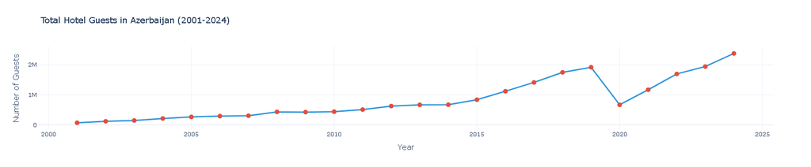

```
📊 KEY GROWTH METRICS:
============================================================
2001: 68,845 guests
2024: 2,380,247 guests
Total Growth (2001-2024): 3357.4%

Pre-COVID (2019): 1,919,765 guests
COVID Low (2020): 668,813 guests
COVID Impact: -65.2%
Recovery (2024 vs 2019): +24.0%
```

```python
import plotly.express as px
import plotly.graph_objects as go

# Line chart - Overall trend
fig = px.line(df, x='Year', y='Total_Persons',
              title='Total Hotel Guests in Azerbaijan (2001-2024)',
              markers=True)

fig.update_traces(
    line_color='#3498db',
    line_width=3,
    marker=dict(size=10, color='#e74c3c')
)

fig.update_layout(
    template='plotly_white',
    height=500,
    xaxis_title='Year',
    yaxis_title='Number of Guests',
    hovermode='x unified',
    font=dict(size=13)
)

fig.show()

# Key statistics
print("\n📊 KEY GROWTH METRICS:")
print("="*60)
print(f"2001: {df[df['Year']==2001]['Total_Persons'].values[0]:,.0f} guests")
print(f"2024: {df[df['Year']==2024]['Total_Persons'].values[0]:,.0f} guests")

growth_2001_2024 = ((df[df['Year']==2024]['Total_Persons'].values[0] /
                     df[df['Year']==2001]['Total_Persons'].values[0]) - 1) * 100
print(f"Total Growth (2001-2024): {growth_2001_2024:.1f}%")

# Pre-COVID
print(f"\nPre-COVID (2019): {df[df['Year']==2019]['Total_Persons'].values[0]:,.0f} guests")
# COVID
print(f"COVID Low (2020): {df[df['Year']==2020]['Total_Persons'].values[0]:,.0f} guests")
covid_drop = ((df[df['Year']==2020]['Total_Persons'].values[0] /
               df[df['Year']==2019]['Total_Persons'].values[0]) - 1) * 100
print(f"COVID Impact: {covid_drop:.1f}%")

# Recovery
recovery_2024 = ((df[df['Year']==2024]['Total_Persons'].values[0] /
                  df[df['Year']==2019]['Total_Persons'].values[0]) - 1) * 100
print(f"Recovery (2024 vs 2019): {recovery_2024:+.1f}%")
```

### 🌍 Citizens vs Foreign Tourists

How has the composition of tourism changed over the years?

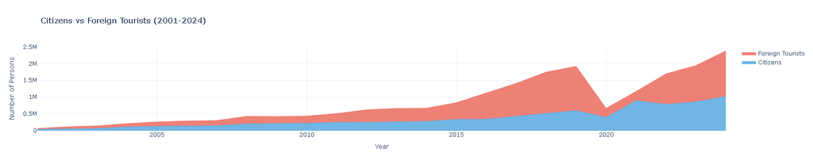

```
🌍 FOREIGN TOURIST ANALYSIS:
============================================================
2001: 24,151 foreign tourists
2024: 1,354,027 foreign tourists
Growth: 5506.5%
```

```python
# Stacked area chart
fig = go.Figure()

fig.add_trace(go.Scatter(
    x=df['Year'],
    y=df['Citizens_Persons'],
    name='Citizens',
    mode='lines',
    stackgroup='one',
    fillcolor='rgba(52, 152, 219, 0.7)',
    line=dict(width=0.5, color='rgb(52, 152, 219)')
))

fig.add_trace(go.Scatter(
    x=df['Year'],
    y=df['Foreigners_Persons'],
    name='Foreign Tourists',
    mode='lines',
    stackgroup='one',
    fillcolor='rgba(231, 76, 60, 0.7)',
    line=dict(width=0.5, color='rgb(231, 76, 60)')
))

fig.update_layout(
    title='Citizens vs Foreign Tourists (2001-2024)',
    xaxis_title='Year',
    yaxis_title='Number of Persons',
    template='plotly_white',
    height=500,
    hovermode='x unified'
)

fig.show()

# Foreign tourist growth
print("\n🌍 FOREIGN TOURIST ANALYSIS:")
print("="*60)
foreign_2001 = df[df['Year']==2001]['Foreigners_Persons'].values[0]
foreign_2024 = df[df['Year']==2024]['Foreigners_Persons'].values[0]
print(f"2001: {foreign_2001:,.0f} foreign tourists")
print(f"2024: {foreign_2024:,.0f} foreign tourists")
print(f"Growth: {((foreign_2024/foreign_2001)-1)*100:.1f}%")
```

## 🦠 COVID-19 Pandemic Impact

The pandemic dramatically affected tourism. Let's analyze the recovery.

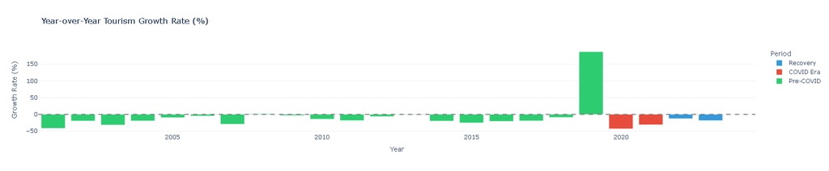

```python
# Year-over-year growth rate
df['Growth_Rate'] = df['Total_Persons'].pct_change() * 100

# Create period labels
df['Period'] = df['Year'].apply(lambda x:
    'Pre-COVID' if x < 2020
    else 'COVID Era' if x <= 2021
    else 'Recovery'
)

# Bar chart
fig = px.bar(df, x='Year', y='Growth_Rate',
             title='Year-over-Year Tourism Growth Rate (%)',
             color='Period',
             color_discrete_map={
                 'Pre-COVID': '#2ecc71',
                 'COVID Era': '#e74c3c',
                 'Recovery': '#3498db'
             })

fig.add_hline(y=0, line_dash="dash", line_color="gray", line_width=2)

fig.update_layout(
    template='plotly_white',
    height=500,
    xaxis_title='Year',
    yaxis_title='Growth Rate (%)',
    showlegend=True
)

fig.show()
```

## 🔍 Key Findings

### 1. Extraordinary Long-term Growth 📈

- Tourism grew from **68,845 persons (2001)** to **2,380,247 persons (2024)**
- This represents a **staggering 3,357% increase** over 23 years
- Average annual growth rate: ~16%

### 3. Foreign Tourist Boom 🌍

- Foreign tourists increased from 24,151 (2001) to 1,354,027 (2024)
- **5,506% growth** - even faster than domestic tourism
- International appeal of Azerbaijan is accelerating
- Formula 1, Eurovision legacy, and visa policies contributing

### 4. Steady Domestic Tourism 🏠

- Citizens' hotel usage grew from 44,694 (2001) to 1,026,220 (2024)
- 2,197% increase showing growing domestic travel culture
- Middle class expansion driving internal tourism

### 5. Economic Impact 💰

- Hotel industry becoming major GDP contributor
- Thousands of jobs created in tourism sector
- Infrastructure development following demand
- Regional economic diversification

## 💡 Recommendations

### For Tourists Planning to Visit Azerbaijan:

#### 🌸 **Spring (April-May)**

- ✅ Pleasant weather (15-25°C)
- ✅ Moderate prices
- ✅ Fewer crowds than summer
- ✅ Novruz celebrations in March
- ❌ Some mountain areas still cold

#### ☀️ **Summer (June-August)** - Peak Season

- ✅ All attractions open
- ✅ Beach season (Caspian Sea)
- ✅ Vibrant nightlife and festivals
- ❌ Very hot in Baku (35-40°C)
- ❌ Highest prices (+40% premium)
- ❌ Crowded tourist sites

#### ❄️ **Winter (November-February)** - Budget Option

- ✅ Lowest prices (up to 50% cheaper)
- ✅ Shahdag ski resort
- ✅ Authentic local experience
- ❌ Some attractions closed
- ❌ Cold weather

### For Tourism Industry:

1. **Diversify seasonal offerings** - Develop winter tourism products
2. **Sustainable growth** - Infrastructure must keep pace with demand
3. **Regional development** - Expand beyond Baku
4. **Quality over quantity** - Maintain service standards
5. **Digital marketing** - Target emerging markets

### For Policymakers:

1. Continue visa liberalization policies
2. Invest in regional airport connectivity
3. Protect cultural and natural heritage
4. Develop sustainable tourism framework
5. Support SMEs in tourism sector

## 📝 Conclusion

This comprehensive analysis of Azerbaijan's hotel occupancy data (2001-2024) reveals a **remarkable transformation** in the country's tourism landscape:

✅ **Exponential Growth**: Over 3,000% increase in 23 years  
✅ **COVID Resilience**: Strong recovery exceeding pre-pandemic levels  
✅ **International Appeal**: Foreign tourists growing faster than domestic  
✅ **Economic Engine**: Tourism becoming vital GDP contributor

### When to Visit Azerbaijan?

**The answer depends on your priorities:**

- 🏆 **Best overall experience**: September-October
- 💰 **Budget travelers**: December-February
- 🏖️ **Beach lovers**: July-August
- 🎭 **Cultural enthusiasts**: March (Novruz)
- 🏔️ **Winter sports**: January-March (Shahdag)

Azerbaijan's tourism sector demonstrates **sustainable growth potential** while maintaining its unique cultural identity and natural beauty.

**Project Information:**

- **Data Source**: IDDA Open Data Portal (opendata.az)
- **Dataset**: Hotel Occupancy Statistics (2001-2024)
- **Category**: Tourism
- **Analysis Date**: January 2026
- **Tools**: Python, Pandas, Plotly, Seaborn

*Thank you for exploring this analysis!*